# Курсовая работа № 2

#### 5.1 Проверка возможных зависимостей между "Performance Score" и показателями "Daily Error Rate" / "90-day Complaints" / "Pay"

```python
# total_transgressions - общие прегрешения = суммарные нарушения
prod_err_com_pay = pd.read_sql("""SELECT
                                        "Performance Score" AS Performance_Score,
                                         AVG("90-day Complaints") AS avg_90_day_сomplaints,
                                         AVG("Daily Error Rate") AS avg_daily_error_rate,
                                         AVG("Daily Error Rate") + AVG("90-day Complaints") AS total_transgressions,
                                         AVG(CAST("Pay" AS decimal)) / 15 AS pay
                                  FROM production_staff
                                       WHERE "Employment Status"='Active'
                                            GROUP BY "Performance Score"
                                                    ORDER BY total_transgressions DESC
                                                                                       """, connect)
prod_err_com_pay.index = prod_err_com_pay.performance_score
prod_err_com_pay = prod_err_com_pay.drop(['performance_score'], axis = 1)
prod_err_com_pay
```

| performance_score | avg_90_day_сomplaints | avg_daily_error_rate | total_transgressions | pay |
| --- | --- | --- | --- | --- |
| Needs Improvement | 1.000000 | 1.750000 | 2.750000 | 2.066667 |
| PIP | 1.000000 | 1.333333 | 2.333333 | 1.333333 |
| N/A- too early to review | 0.428571 | 1.142857 | 1.571429 | 1.390476 |
| 90-day meets | 0.000000 | 1.333333 | 1.333333 | 1.330556 |
| Fully Meets | 0.231884 | 0.681159 | 0.913043 | 1.558952 |
| Exceptional | 0.250000 | 0.500000 | 0.750000 | 1.500000 |
| Exceeds | 0.000000 | 0.307692 | 0.307692 | 1.649231 |

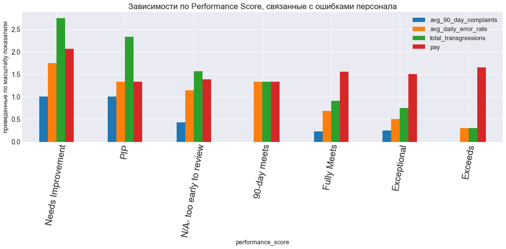

```python
plt.rcParams["figure.figsize"] = (18, 5)

matplotlib.rc('xtick', labelsize=19)
matplotlib.rc('ytick', labelsize=14)
plt.rcParams.update({'font.size': 13})

prod_err_com_pay.plot.bar()
plt.title("Зависимости по Performance Score, связанные с ошибками персонала", fontsize=17) # ШРИФТ
plt.ylabel('приведенные по масштабу показатели')
plt.xticks(rotation=80)
plt.show()
```

##### 5.1.1 Гипотезы зависимостей между квалификацией по шкале Performance Score и ошибками персонала

*1) Есть зависимость между "Performance Score" и "Daily Error Rate" (чем выше квалификация - тем меньше ошибок).*  
*2) Есть зависимость между "Performance Score" и "90-day Complaints" (чем выше квалификация - тем меньше рекламаций).*  
*3) Есть бесспорная зависимость между "Performance Score" и total_transgressions = суммарным прегрешениям (чем выше квалификация - тем меньше прегрешений).*  
*4) ! Есть милая политкорректная ЗАВИСИМОСТЬ НЕ ОБРАЩАТЬ ВНИМАНИЕ на "прегрешения" при оплате труда*

#### 5.2 Проверка возможных зависимостей между расами Race Desc и показателями "Daily Error Rate" / "90-day Complaints" / "Pay"

```python
race_err_com = pd.read_sql("""SELECT
                                    "Race Desc" AS Race,
                                     AVG("90-day Complaints") AS race_complaints_avg,
                                     AVG("Daily Error Rate") AS race_error_avg,
                                     AVG("Daily Error Rate") + AVG("90-day Complaints") AS race_transgressions,
                                     AVG(CAST("Pay" AS decimal)) / 14.9 AS pay
                                FROM production_staff
                                    WHERE "Employment Status"='Active'
                                         GROUP BY "Race Desc"
                                                  ORDER BY race_transgressions DESC
                                                                                    """, connect)
race_err_com.index = race_err_com.race
race_err_com =race_err_com.drop(['race'], axis = 1)
race_err_com
```

| race | race_complaints_avg | race_error_avg | race_transgressions | pay |
| --- | --- | --- | --- | --- |
| Black or African American | 0.473684 | 1.157895 | 1.631579 | 1.632285 |
| White | 0.228571 | 0.700000 | 0.928571 | 1.585112 |
| Asian | 0.100000 | 0.700000 | 0.800000 | 1.315436 |
| Two or more races | 0.250000 | 0.500000 | 0.750000 | 1.204027 |
| American Indian or Alaska Native | 0.000000 | 0.000000 | 0.000000 | 1.291946 |
| Hispanic | 0.000000 | 0.000000 | 0.000000 | 3.557047 |

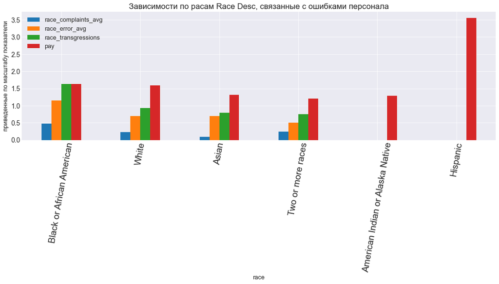

```python
plt.rcParams["figure.figsize"] = (18, 5)

matplotlib.rc('xtick', labelsize=19)
matplotlib.rc('ytick', labelsize=14)
plt.rcParams.update({'font.size': 13})

race_err_com.plot.bar()
plt.title("Зависимости по расам Race Desc, связанные с ошибками персонала", fontsize=17) # ШРИФТ
plt.ylabel('приведенные по масштабу показатели')
plt.xticks(rotation=80)
plt.show()
```

##### 5.2.1 Гипотезы зависимостей между категориями рас в Race Desc и ошибками персонала

*1) Есть БЕССПОРНАЯ зависимость между "Race Desc" и race_transgressions - суммарными прегрешениями у тех рас, где они (race_transgressions) вообще встречаются.*  
*2) ! Есть БЕССПОРНАЯ зависимость **ПЛАТИТЬ БОЛЬШЕ ТЕМ расам, У КОТОРЫХ** race_transgressions - **СУММАРНЫЕ ПРЕГРЕШЕНИЯ - БОЛЬШЕ** (из тех рас, где они (race_transgressions) вообще встречаются. Сбывшаяся мечта BLM.*

#### 5.3 Проверка возможных зависимостей между Manager Name и показателями "Daily Error Rate" / "90-day Complaints" / "Pay"

```python
# подобран коэффициент деления, обеспечивший равенство на графике manager_persons_transgressions и manager_persons_pay_avg
# у manager_name с наибольшим manager_persons_transgressions
manager_err_com = pd.read_sql("""SELECT
                                       "Manager Name" AS Manager_Name,
                                        AVG("90-day Complaints") AS manager_persons_complaints_avg,
                                        AVG("Daily Error Rate") AS manager_persons_err_avg,
                                        AVG("Daily Error Rate") +  AVG("90-day Complaints") AS manager_persons_transgressions,
                                         AVG(CAST("Pay" AS decimal)) / 12.75 AS manager_persons_pay_avg
                                  FROM production_staff
                                      WHERE "Employment Status"='Active'
                                           GROUP BY "Manager Name"
                                                   ORDER BY manager_persons_transgressions DESC """, connect)

manager_err_com.index = manager_err_com.manager_name
manager_err_com =manager_err_com.drop(['manager_name'], axis = 1)
manager_err_com
```

| manager_name | manager_persons_complaints_avg | manager_persons_err_avg | manager_persons_transgressions | manager_persons_pay_avg |
| --- | --- | --- | --- | --- |
| Amy Dunn | 0.625000 | 0.875000 | 1.500000 | 1.500000 |
| Elijiah Gray | 0.307692 | 1.076923 | 1.384615 | 1.646998 |
| David Stanley | 0.214286 | 1.071429 | 1.285714 | 1.466387 |
| Brannon Miller | 0.230769 | 1.000000 | 1.230769 | 1.574661 |
| Michael Albert | 0.416667 | 0.750000 | 1.166667 | 1.738562 |
| Ketsia Liebig | 0.333333 | 0.800000 | 1.133333 | 1.647059 |
| Kissy Sullivan | 0.333333 | 0.666667 | 1.000000 | 1.694678 |
| Webster Butler | 0.000000 | 0.500000 | 0.500000 | 1.764706 |
| Kelley Spirea | 0.000000 | 0.333333 | 0.333333 | 1.599739 |
| Elisa Bramante | 0.000000 | 0.000000 | 0.000000 | 4.204793 |

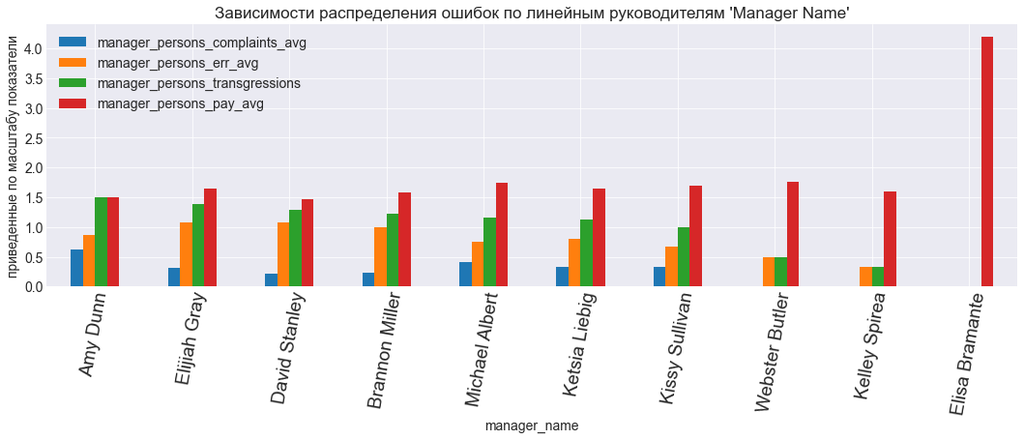

```python
plt.rcParams["figure.figsize"] = (18, 5)

matplotlib.rc('xtick', labelsize=19)
matplotlib.rc('ytick', labelsize=14)
plt.rcParams.update({'font.size': 14})

manager_err_com.plot.bar()
plt.title("Зависимости распределения ошибок по линейным руководителям 'Manager Name'", fontsize=17) # ШРИФТ
plt.ylabel('приведенные по масштабу показатели')
plt.xticks(rotation=80)
plt.show()
```

##### 5.3.1 Гипотезы зависимостей между Manager Name и ошибками персонала

*1) Есть БЕССПОРНАЯ зависимость между именами в списке "Manager Name" и manager_persons_transgressions - средними суммарными прегрешениями персонала.*  
*2) Есть ПРОТИВОЕСТЕСТВЕННАЯ НЕЗАВИСИМОСТЬ между manager_persons_transgressions персонала у "Manager Name" и "Pay" исполнителям этих transgressions (см. manager_persons_pay_avg), на которую (оплату) начальники, похоже, не реагируют.*

#### 5.4 Проверка возможных зависимостей между СПЕЦИАЛЬНОСТЬЮ (Position) и "Daily Error Rate" / "90-day Complaints" / "Pay"

```python
prod_pos = pd.read_sql("""SELECT
                                "Position" AS position,
                                 AVG("90-day Complaints") AS complaints_avg,
                                 AVG("Daily Error Rate") AS error_avg,
                                 AVG("Daily Error Rate") +  AVG("90-day Complaints") AS pos_transgressions,
                                 AVG(CAST("Pay" AS decimal)) / 20 AS pay
                          FROM production_staff
                              WHERE "Employment Status"='Active'
                                   GROUP BY "Position"
                                           ORDER BY pos_transgressions DESC """, connect)
prod_pos.index = prod_pos.position
prod_pos = prod_pos.drop(['position'], axis = 1)
prod_pos
```

| position | complaints_avg | error_avg | pos_transgressions | pay |
| --- | --- | --- | --- | --- |
| Production Technician I | 0.256757 | 0.851351 | 1.108108 | 0.954399 |
| Production Technician II | 0.347826 | 0.739130 | 1.086957 | 1.256750 |
| Production Manager | 0.000000 | 0.000000 | 0.000000 | 2.680556 |

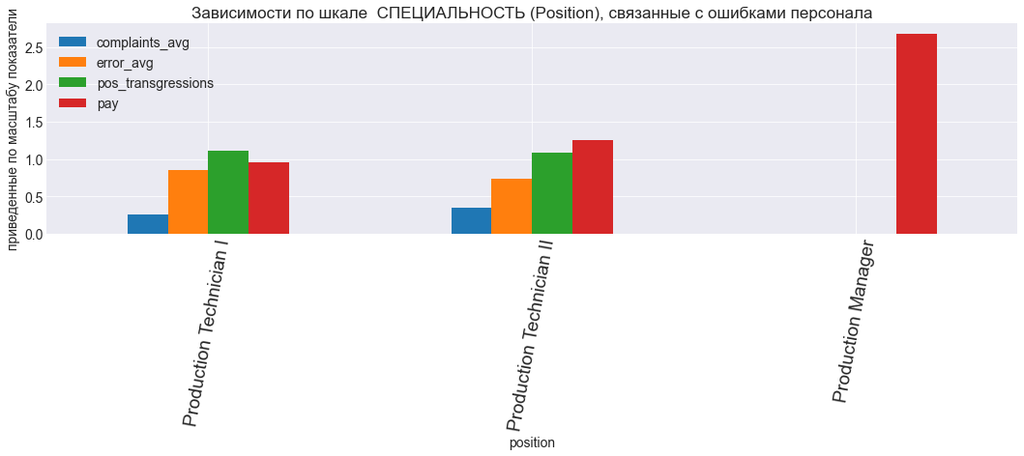

```python
plt.rcParams["figure.figsize"] = (18, 4)

matplotlib.rc('xtick', labelsize=19)
matplotlib.rc('ytick', labelsize=14)
plt.rcParams.update({'font.size': 14})

prod_pos.plot.bar()
plt.title("Зависимости по шкале  СПЕЦИАЛЬНОСТЬ (Position), связанные с ошибками персонала", fontsize=17) # ШРИФТ
plt.ylabel('приведенные по масштабу показатели')
plt.xticks(rotation=80)
plt.show()
```

##### 5.4.1 Гипотезы зависимостей между СПЕЦИАЛЬНОСТЬ (Position) и ошибками персонала

*1) Есть разнонаправленные зависимости у Production Technician I и Production Technician II по "Daily Error Rate" и "90-day Complaints" (у Technician I больше "Daily Error Rate", у Technician II больше "90-day Complaints").*  
*2) Есть ЛОГИЧНАЯ ОБРАТНАЯ зависимость между суммарными прегрешениями pos_transgressions и "Pay" исполнителям этих прегрешений (оплата больше у тех, кто меньше косячит).*

## 6. Поиск гипотез зависимостей показателей таблицы "recruiting_costs"

```python
costs = pd.read_sql("select * from recruiting_costs", connect)
costs.head(1)
```

|  | id | Employment Source | January | February | March | April | May | June | July | August | September | October | November | December | Total |
| --- | --- | --- | --- | --- | --- | --- | --- | --- | --- | --- | --- | --- | --- | --- | --- |
| 0 | 1 | Billboard | 520 | 520 | 520 | 520 | 0 | 0 | 612 | 612 | 729 | 749 | 910 | 500 | 6192 |

```python
costs_inf = pd.read_sql( "select * from INFORMATION_SCHEMA.COLUMNS where TABLE_NAME='recruiting_costs'" , connect)
costs_inf
```

[output not shown]

#### 6.1 Проверка возможных зависимостей между операторами Employment Source и затратами на perf_scoreid (квалификацию) персонала

```python
costs_avg2 = pd.read_sql("""SELECT
                                  "Employee Source" AS Employee_Source,
                                   AVG(perf_scoreid) AS perf_scoreid_avg,
                                   AVG("Total") / AVG(perf_scoreid) / 100 AS price_of_the_perf_scoreid
                            FROM hr_dataset

                                 JOIN  recruiting_costs

                                     ON hr_dataset."Employee Source" = recruiting_costs."Employment Source"
                                         WHERE "Employment Status"='Active' AND perf_scoreid < 9
                                              GROUP BY "Employee Source"
                                                       ORDER BY price_of_the_perf_scoreid
                                                                                          """, connect)
costs_avg2.index = costs_avg2.employee_source
costs_avg2 = costs_avg2.drop(['employee_source'], axis = 1)
costs_avg2
```

| employee_source | perf_scoreid_avg | price_of_the_perf_scoreid |
| --- | --- | --- |
| Employee Referral | 2.550000 | 0.000000 |
| Information Session | 3.000000 | 0.000000 |
| Internet Search | 2.750000 | 0.000000 |
| Word of Mouth | 2.400000 | 0.000000 |
| Vendor Referral | 3.000000 | 0.000000 |
| Glassdoor | 2.666667 | 0.000000 |
| Professional Society | 3.384615 | 3.545455 |
| Pay Per Click - Google | 2.562500 | 13.693659 |
| Other | 2.800000 | 14.267857 |
| Search Engine - Google Bing Yahoo | 3.111111 | 16.659643 |
| Monster.com | 2.666667 | 21.600000 |
| Billboard | 2.818182 | 21.971613 |
| On-campus Recruiting | 3.125000 | 24.000000 |
| Careerbuilder | 3.000000 | 25.966667 |
| Social Networks - Facebook Twitter etc | 2.000000 | 27.865000 |
| Website Banner Ads | 2.333333 | 30.612857 |
| Newspager/Magazine | 2.700000 | 30.707407 |
| MBTA ads | 3.416667 | 32.136585 |
| Diversity Job Fair | 3.000000 | 33.403333 |

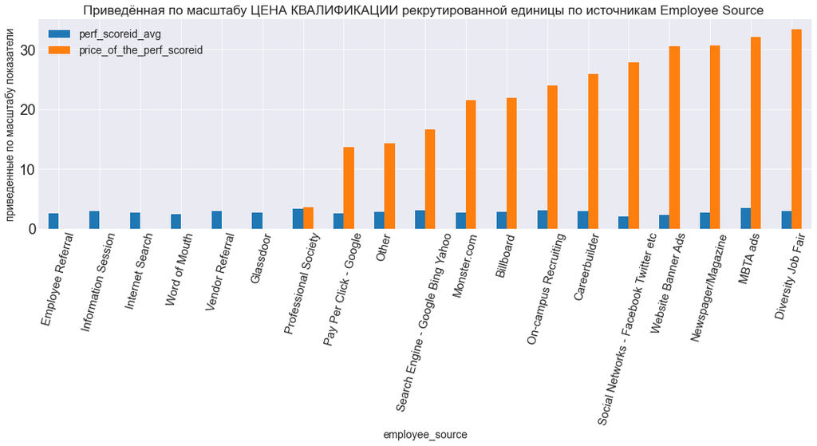

```python
plt.rcParams["figure.figsize"] = (18, 5)

matplotlib.rc('xtick', labelsize=15)
matplotlib.rc('ytick', labelsize=19)
plt.rcParams.update({'font.size': 14})

costs_avg2.plot.bar()
plt.title("Приведённая по масштабу ЦЕНА КВАЛИФИКАЦИИ рекрутированной единицы по источникам Employee Source ", fontsize=17)
plt.ylabel('приведенные по масштабу показатели')
plt.xticks(rotation=75)
plt.show()
```

##### 6.1.1 Гипотеза зависимости между поставщиком персонала Employee Source и ценой квалификацией персонала, т.е. ЦЕНОЙ УСЛУГИ

*1) Есть зависимость между затратами на perf_scoreid (квалификацию) персонала и КОНКРЕТНЫМИ операторами "Employee Source, поставляющими этот персонал".*

#### 6.2 Проверка возможных зависимостей между операторами Employment Source и затратами на "нетекучесть кадров"

```python
costs_avg4 = pd.read_sql("""SELECT
                                  "Employee Source" AS Employee_Source,
                                   AVG("Days Employed") / 1000 AS days,
                                   AVG("Total") / AVG("Days Employed")  AS price_of_a_day_of_employment
                            FROM hr_dataset

                                 JOIN  recruiting_costs

                                      ON hr_dataset."Employee Source" = recruiting_costs."Employment Source"
                                         WHERE "Employment Status"='Active' AND perf_scoreid < 9
                                              GROUP BY "Employee Source"
                                                       ORDER BY price_of_a_day_of_employment
                                                                                             """, connect)
costs_avg4.index = costs_avg4.employee_source
costs_avg4 = costs_avg4.drop(['employee_source'], axis = 1)
costs_avg4
```

| employee_source | days | price_of_a_day_of_employment |
| --- | --- | --- |
| Employee Referral | 1.440000 | 0.000000 |
| Information Session | 2.361000 | 0.000000 |
| Vendor Referral | 1.625333 | 0.000000 |
| Internet Search | 1.382500 | 0.000000 |
| Glassdoor | 1.522333 | 0.000000 |
| Word of Mouth | 1.795200 | 0.000000 |
| Professional Society | 1.550077 | 0.774155 |
| Other | 2.742600 | 1.456647 |
| Pay Per Click - Google | 1.523937 | 2.302588 |
| Search Engine - Google Bing Yahoo | 2.130556 | 2.432699 |
| Social Networks - Facebook Twitter etc | 2.061667 | 2.703153 |
| Billboard | 2.182091 | 2.837645 |
| Careerbuilder | 2.428000 | 3.208402 |
| Monster.com | 1.789583 | 3.218626 |
| Website Banner Ads | 1.676667 | 4.260239 |
| Newspager/Magazine | 1.672000 | 4.958732 |
| Diversity Job Fair | 1.981000 | 5.058556 |
| On-campus Recruiting | 1.392000 | 5.387931 |
| MBTA ads | 1.775667 | 6.183593 |

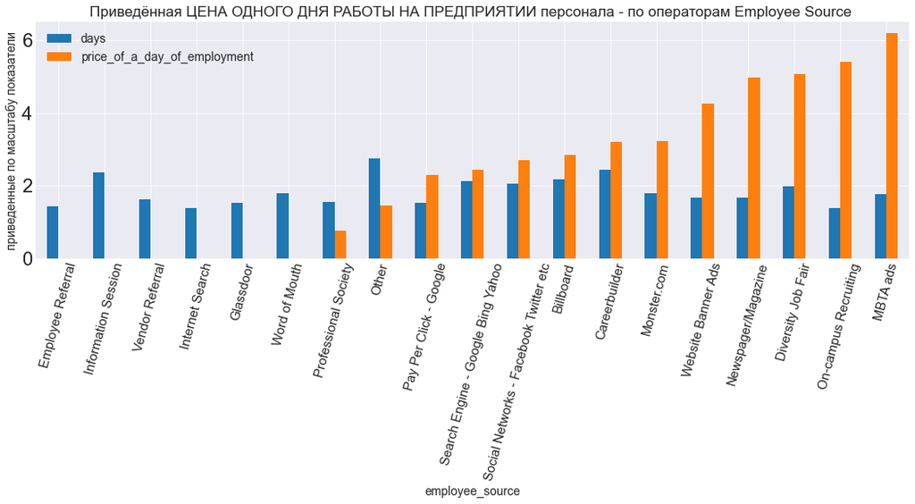

```python
plt.rcParams["figure.figsize"] = (18, 5)

matplotlib.rc('xtick', labelsize=15)
matplotlib.rc('ytick', labelsize=22)
plt.rcParams.update({'font.size': 14})

costs_avg4.plot.bar()
plt.title("Приведённая ЦЕНА ОДНОГО ДНЯ РАБОТЫ НА ПРЕДПРИЯТИИ персонала - по операторам Employee Source ", fontsize=17)
plt.ylabel('приведенные по масштабу показатели')
plt.xticks(rotation=75)
plt.show()
```

##### 6.2.1 Гипотеза зависимости между поставщиком персонала Employee Source и затратами на "нетекучесть кадров"

*1) Есть зависимость между ценой каждого ДНЯ РАБОТЫ персонала на предприятии и КОНКРЕТНЫМИ ОПЕРАТОРАМИ "Employee Source", предоставившими этот персонал.*

## 7. Поиск гипотез зависимостей показателей таблицы "salary_grid"

```python
salary = pd.read_sql("select * from salary_grid", connect)
salary
```

|  | id | Position | Salary Min | Salary Mid | Salary Max | Hourly Min | Hourly Mid | Hourly Max |
| --- | --- | --- | --- | --- | --- | --- | --- | --- |
| 0 | 1 | Administrative Assistant | 30000 | 40000 | 50000 | 14.42 | 19.23 | 24.04 |
| 1 | 2 | Sr. Administrative Assistant | 35000 | 45000 | 55000 | 16.83 | 21.63 | 26.44 |
| 2 | 3 | Accountant I | 42274 | 51425 | 62299 | 20.32 | 24.72 | 29.95 |
| 3 | 4 | Accountant II | 50490 | 62158 | 74658 | 24.27 | 29.88 | 35.89 |
| 4 | 5 | Sr. Accountant | 63264 | 76988 | 92454 | 30.42 | 37.01 | 44.45 |
| 5 | 6 | Network Engineer | 50845 | 66850 | 88279 | 24.44 | 32.14 | 42.44 |
| 6 | 7 | Sr. Network Engineer | 79428 | 99458 | 120451 | 38.19 | 47.82 | 57.91 |
| 7 | 8 | Database Administrator | 50569 | 68306 | 93312 | 24.31 | 32.84 | 44.86 |
| 8 | 9 | Sr. DBA | 92863 | 116007 | 139170 | 44.65 | 55.77 | 66.91 |
| 9 | 10 | Production Technician I | 30000 | 40000 | 50000 | 14.42 | 19.23 | 24.04 |
| 10 | 11 | Production Technician II | 38000 | 48000 | 58000 | 18.27 | 23.08 | 27.88 |
| 11 | 12 | Lead Production Technician | 45000 | 55000 | 65000 | 21.63 | 26.44 | 31.25 |

### 7.1 часовая оплата

#### 7.1.1 Проверка возможных зависимостей между СРЕДНЕЙ реальной часовой оплатой и предписанной нормативом

```python
hourly1 = pd.read_sql("""SELECT
                                     position AS position,
                                     AVG("Pay Rate") AS real_avg_pay,
                                     AVG("Hourly Mid") AS prescribed_hourly_mid,
                                     AVG("Pay Rate") < AVG("Hourly Mid") AS correct
                             FROM hr_dataset
                                  JOIN  salary_grid
                                      ON hr_dataset.position = salary_grid."Position"
                                         WHERE "Employment Status"='Active' AND perf_scoreid < 9
                                              GROUP BY Position
                                                        ORDER BY correct DESC
                                                                              """, connect)
hourly1.index = hourly1.position
hourly1 = hourly1.drop(['position'], axis = 1)
hourly1
```

| position | real_avg_pay | prescribed_hourly_mid | correct |
| --- | --- | --- | --- |
| Production Technician I | 18.947910 | 19.230000 | True |
| Sr. Accountant | 34.950001 | 37.009998 | True |
| Network Engineer | 39.000000 | 32.139999 | False |
| Accountant I | 26.833333 | 24.719999 | False |
| Database Administrator | 35.880000 | 32.840000 | False |
| Production Technician II | 25.010909 | 23.080000 | False |
| Sr. Network Engineer | 53.000000 | 47.820000 | False |

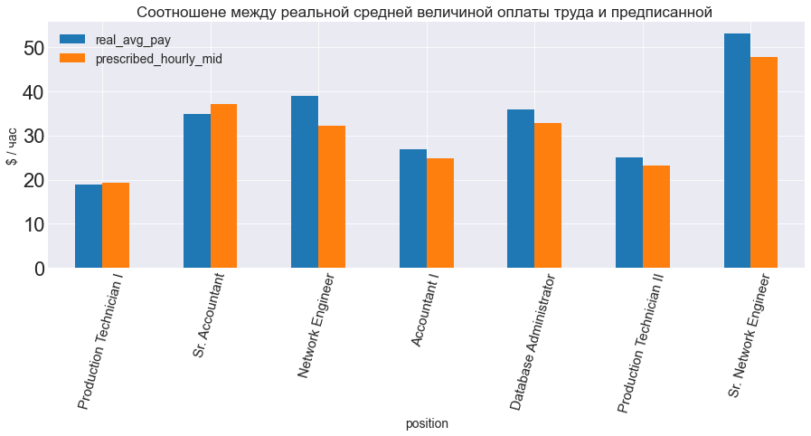

```python
plt.rcParams["figure.figsize"] = (15, 5)

matplotlib.rc('xtick', labelsize=15)
matplotlib.rc('ytick', labelsize=22)
plt.rcParams.update({'font.size': 14})

hourly1.plot.bar()
plt.title("Cоотношене между реальной средней величиной оплаты труда и предписанной ", fontsize=17)
plt.ylabel('$ / час')
plt.xticks(rotation=75)
plt.show()
```

##### 7.1.1.1 Гипотеза о не зависимости между реальностью и нормативом

*1) Есть зависимость от внутренней потребности увеличить реальную СРЕДНЮЮ оплату труда относительно предписанной в 5 случаях из 7.*

#### 7.1.2 Проверка возможных зависимостей между МАКСИМАЛЬНОЙ реальной часовой оплатой и предписанной нормативом

```python
hourly2 = pd.read_sql("""SELECT
                                     position AS position,
                                     MAX("Pay Rate") AS real_max_pay,
                                     AVG("Hourly Max") AS prescribed_hourly_max,
                                     MAX("Pay Rate") < AVG("Hourly Max") AS correct
                             FROM hr_dataset
                                  JOIN  salary_grid
                                      ON hr_dataset.position = salary_grid."Position"
                                         WHERE "Employment Status"='Active'
                                              GROUP BY Position
                                                      ORDER BY correct DESC
                                                                 """, connect)
hourly2.index = hourly2.position
hourly2 = hourly2.drop(['position'], axis = 1)
hourly2
```

| position | real_max_pay | prescribed_hourly_max | correct |
| --- | --- | --- | --- |
| Accountant I | 29.00 | 29.950001 | True |
| Administrative Assistant | 21.50 | 24.040001 | True |
| Database Administrator | 42.75 | 44.860001 | True |
| Sr. Network Engineer | 55.20 | 57.910000 | True |
| Sr. Accountant | 34.95 | 44.450001 | True |
| Network Engineer | 49.10 | 42.439999 | False |
| Production Technician II | 29.00 | 27.879999 | False |
| Production Technician I | 24.50 | 24.040001 | False |

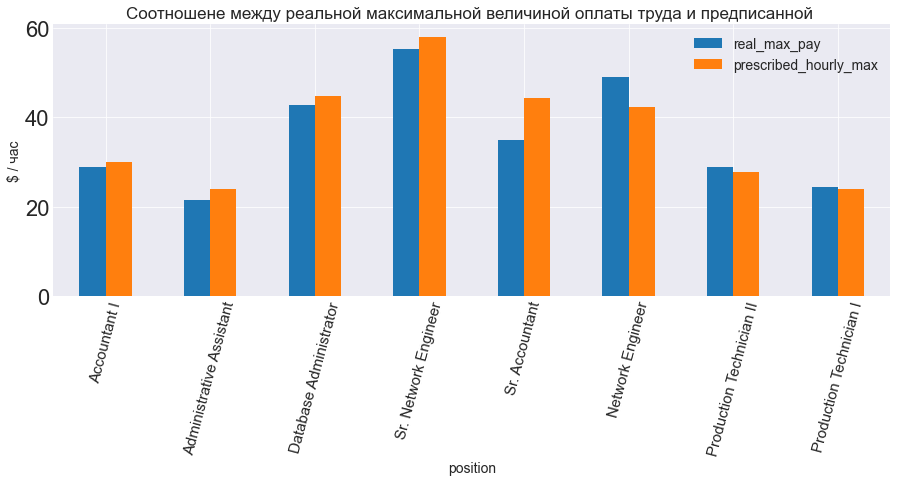

```python
plt.rcParams["figure.figsize"] = (15, 5)

matplotlib.rc('xtick', labelsize=15)
matplotlib.rc('ytick', labelsize=22)
plt.rcParams.update({'font.size': 14})

hourly2.plot.bar()
plt.title("Cоотношене между реальной максимальной величиной оплаты труда и предписанной ", fontsize=17)
plt.ylabel('$ / час')
plt.xticks(rotation=75)
plt.show()
```

#### 7.1.3 Проверка возможных зависимостей между МИНИМАЛЬНОЙ реальной часовой оплатой и предписанной нормативом

```python
hourly3 = pd.read_sql("""SELECT
                                     position AS position,
                                      MIN("Pay Rate") AS real_min_pay,
                                      AVG("Hourly Min") AS prescribed_hourly_min,
                                      MIN("Pay Rate") > AVG("Hourly Min") AS correct
                              FROM hr_dataset
                                  JOIN  salary_grid
                                      ON hr_dataset.position = salary_grid."Position"
                                         WHERE "Employment Status"='Active'
                                              GROUP BY Position
                                                                 """, connect)
hourly3.index = hourly3.position
hourly3 = hourly3.drop(['position'], axis = 1)
hourly3
```

| position | real_min_pay | prescribed_hourly_min | correct |
| --- | --- | --- | --- |
| Production Technician I | 14.00 | 14.420000 | False |
| Sr. Network Engineer | 53.00 | 38.189999 | True |
| Sr. Accountant | 34.95 | 30.420000 | True |
| Production Technician II | 22.00 | 18.270000 | True |
| Network Engineer | 27.00 | 24.440001 | True |
| Accountant I | 23.00 | 20.320000 | True |
| Administrative Assistant | 16.56 | 14.420000 | True |
| Database Administrator | 30.20 | 24.309999 | True |

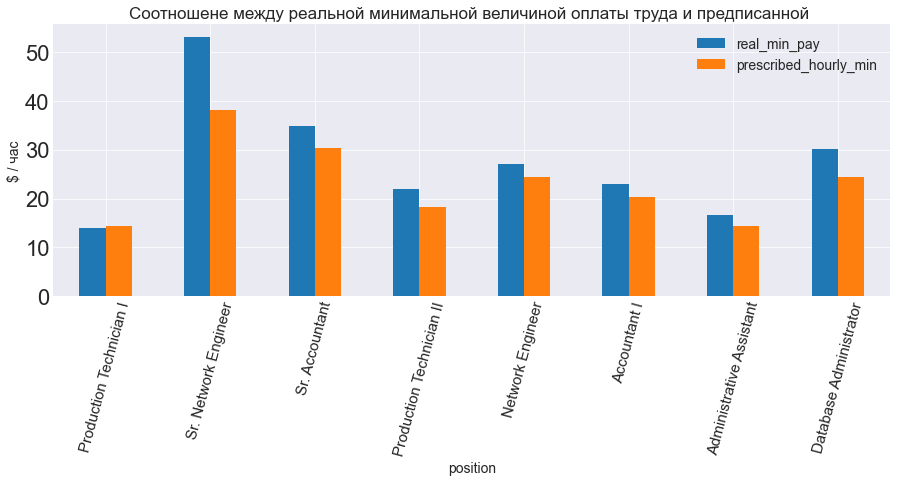

```python
plt.rcParams["figure.figsize"] = (15, 5)

matplotlib.rc('xtick', labelsize=15)
matplotlib.rc('ytick', labelsize=22)
plt.rcParams.update({'font.size': 14})

hourly3.plot.bar()
plt.title("Cоотношене между реальной минимальной величиной оплаты труда и предписанной ", fontsize=17)
plt.ylabel('$ / час')
plt.xticks(rotation=75)
plt.show()
```

### 7.2 Проверка возможных зависимостей между средней годовой оплатой и предписанной

```python
salary = pd.read_sql("select * from salary_grid", connect)
salary.head(1)
```

|  | id | Position | Salary Min | Salary Mid | Salary Max | Hourly Min | Hourly Mid | Hourly Max |
| --- | --- | --- | --- | --- | --- | --- | --- | --- |
| 0 | 1 | Administrative Assistant | 30000 | 40000 | 50000 | 14.42 | 19.23 | 24.04 |

```python
salary3 = pd.read_sql("""SELECT
                              hr_dataset."position" AS position,
                              ROUND(AVG("Pay Rate") * 40 * 52) AS salary,
                              AVG("Salary Mid") AS Salary_Mid_prescribed,
                              ROUND(AVG("Pay Rate") * 40 * 52) <  AVG("Salary Mid") AS correct

                        FROM hr_dataset

                                  JOIN  salary_grid

                                      ON  hr_dataset.position = salary_grid."Position"
                                         WHERE "Employment Status"='Active'
                                              GROUP BY Position
                                                      ORDER BY salary DESC
                                                                           """, connect)
salary3.index = salary3.position
salary3 = salary3.drop(['position'], axis = 1)
salary3
```

| position | salary | salary_mid_prescribed | correct |
| --- | --- | --- | --- |
| Sr. Network Engineer | 112528.0 | 99458.0 | False |
| Network Engineer | 85566.0 | 66850.0 | False |
| Database Administrator | 75950.0 | 68306.0 | False |
| Sr. Accountant | 72696.0 | 76988.0 | True |
| Accountant I | 55813.0 | 51425.0 | False |
| Production Technician II | 52112.0 | 48000.0 | False |
| Production Technician I | 39592.0 | 40000.0 | True |
| Administrative Assistant | 39582.0 | 40000.0 | True |

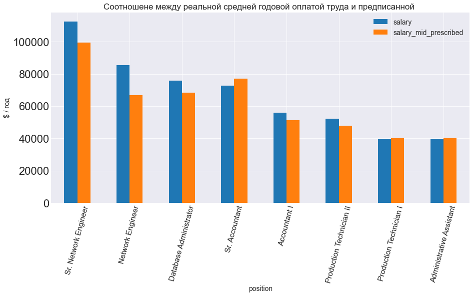

```python
plt.rcParams["figure.figsize"] = (15, 7)

matplotlib.rc('xtick', labelsize=15)
matplotlib.rc('ytick', labelsize=22)
plt.rcParams.update({'font.size': 14})

salary3.plot.bar()
plt.title("Cоотношене между реальной средней годовой оплатой труда и предписанной ", fontsize=17)
plt.ylabel('$ / год')
plt.xticks(rotation=75)
plt.show()
```

### 8. Общий список обнаруженных зависимостей

**-----гендерные**  
*1) Есть зависимость между полом работника и его семейным положением (на предприятии больше замужних женщин чем женатых мужчин)*  
*2) Есть зависимость между полом работника и его стажем (на предприятии у женщин стаж больше чем у мужчин)*  
*3) Есть зависимость между полом работника и его заработком (на предприятии у женщин заработок меньше чем у мужчин)*  
*4) Есть зависимость между полом работника и его квалификацией (на предприятии у женщин квалификация выше, чем у мужчин)*

**-----расовая**  
*1) Есть зависимость между средней квалификацией работников расы и оплатой: **чем ниже квалификация у расы, тем (К УДИВЛЕНИЮ) выше оплата**. Политкорректность одних или наглость (настоичивость) других?*

**-----по департаментам (отделам)**  
*1) Есть зависимость по шкале departments : чем ДАЛЬШЕ ОТ ПРОИЗВОДСТВА - тем ВЫШЕ ОПЛАТА*  
*2) Есть зависимость по шкале departments : чем ДАЛЬШЕ ОТ ПРОИЗВОДСТВА - тем МЕНЬШЕ ЖЕНЩИН и БОЛЬШЕ МУЖЧИН*

**-----по специальностям**  
*1) Есть зависимость по шкале position: чем ДАЛЬШЕ ОТ ПРОИЗВОДСТВА в сторону УПРАВЛЕНИЯ и ПРОДАЖ - тем ВЫШЕ ОПЛАТА (см. pay_rate).*  
*2) Есть зависимость по шкале position : при относительном постоянстве самой величины perf_scoreid_avg, чем БЛИЖЕ К ПРОИЗВОДСТВУ (c'est la vie) - тем НИЖЕ стоимость (или рыночная цена) ЕДИНИЦЫ КВАЛИФИКАЦИИ = Performance (perf_scoreid).*  
*3) ! Есть зависимость по шкале position : при ВЕСЬМА НИЗКОЙ perf_scoreid_avg, НАИБОЛЬШУЮ стоимость (или рыночную цену) ЕДИНИЦЫ Performance (perf_scoreid) имеет специальности, связанные с IT-технологиями ("IT Manager - Infra") и продажами ("Sales Manager") даже в ущерб общего руководства.*

**-----по возрастам**  
*1) Есть зависимость индекса квалификации (perf_scoreid) по шкале age: наибольшей квалификацией обладает персонал в интервале возраста 42-51 год, а наименьшей - персонал начала и конца шкалы.*  
*2) Есть зависимость ОПЛАТЫ (pay_rate) по шкале age: при прямой пропорциональной зависимости между квалификацией о оплатой в середине шкалы, присутствует повышенная (относительно квалификации) оплата в начале и конце шкалы: у молодых - IT, у старых - руководство.*

**-----квалификация и ошибки персонала**  
*1) Есть зависимость между "Performance Score" и "Daily Error Rate" (чем выше квалификация - тем меньше ошибок).*  
*2) Есть зависимость между "Performance Score" и "90-day Complaints" (чем выше квалификация - тем меньше рекламаций).*  
*3) Есть бесспорная зависимость между "Performance Score" и total_transgressions = суммарным прегрешениям (чем выше квалификация - тем меньше прегрешений).*  
*4) ! Есть милая политкорректная ЗАВИСИМОСТЬ НЕ ОБРАЩАТЬ ВНИМАНИЕ на "прегрешения" при оплате труда*

**-----расы и ошибки персонала**  
*1) Есть БЕССПОРНАЯ зависимость между "Race Desc" и race_transgressions - суммарными прегрешениями у тех рас, где они (race_transgressions) вообще встречаются.*  
*2) ! Есть БЕССПОРНАЯ зависимость **ПЛАТИТЬ БОЛЬШЕ ТЕМ расам, У КОТОРЫХ** race_transgressions - **СУММАРНЫЕ ПРЕГРЕШЕНИЯ - БОЛЬШЕ** (из тех рас, где они (race_transgressions) вообще встречаются. Сбывшаяся мечта BLM.*

**-----линейные руководители и ошибки персонала**  
*1) Есть БЕССПОРНАЯ зависимость между именами в списке "Manager Name" и manager_persons_transgressions - средними суммарными прегрешениями персонала.*  
*2) Есть ПРОТИВОЕСТЕСТВЕННАЯ НЕЗАВИСИМОСТЬ между manager_persons_transgressions персонала у "Manager Name" и "Pay" исполнителями этих transgressions (см. manager_persons_pay_avg), на которую (оплату) начальники, похоже, не реагируют.*

**-----специальности и ошибки персонала**  
*1) Есть разнонаправленные зависимости у Production Technician I и Production Technician II по "Daily Error Rate" и "90-day Complaints" (у Technician I больше "Daily Error Rate", у Technician II больше "90-day Complaints").*  
*2) Есть ЛОГИЧНАЯ ОБРАТНАЯ зависимость между суммарными прегрешениями pos_transgressions и "Pay" исполнителям этих прегрешений (оплата больше у тех, кто меньше косячит).*

**-----затраты по операторам на квалификацию**  
*1) Есть зависимость между затратами на perf_scoreid (квалификацию) персонала и КОНКРЕТНЫМИ операторами "Employee Source, поставляющими этот персонал".*

**-----затраты по операторам на постоянство кадров**  
*1) Есть зависимость между ценой каждого ДНЯ РАБОТЫ персонала на предприятии и КОНКРЕТНЫМИ ОПЕРАТОРАМИ "Employee Source", предоставившими этот персонал.*

### 9. Рекомендации

- 1. Столбцы Employee Name и Manager Name заполнять **по одному шаблону** (без запятой и в одном порядке имя/фамилия)
- 1. При прочих равных условиях привлекать больше женщин (у них меньше заработок и выше квалификация)
- 1. Обратить внимание **(СИСТЕМНО)** на оплату персонала в сфере производства: размер, мотивацию роста квалификации и работы без рекламаций и т.д.. Повышать престиж производства и работников производства
- 1. Меньше внимания на BLM
- 1. Оплачивать работу линейных руководителей по результатам работы их подчиненных
- 1. При выборе операторов "Employee Source" руководствоваться экономической целесообразностью затрат на них
- 1. Обратить внимание на причины перерасхода фонда оплаты труда повсеместно: если есть перерасход и никто не крысит, значит дело в неправильном планировании фондов